# 비모수 회귀모형 실습 과제-02

통계학 세미나

2019년 12월 19일까지 제출

이 과제에서는 **R** 라이브러리 `np`에 포함된 자료 `cps71`를 이용할 것이다. 자료 `cps71`는 1971 캐나다 통계청이 교육수주이 비슷한 205명의 남자들에 대한 나이(`age`)와 임금(로그로 변환 된 값, `logwage`) 자료이다.

**과제는 사용한 R 프로그램과 그림을 출력하여 제출하시오.**

```r
#install.packages("np")
library("np")
data("cps71")
head(cps71)
```

```
##   logwage age
## 1 11.1563  21
## 2 12.8131  22
## 3 13.0960  22
## 4 11.6952  22
## 5 11.5327  22
## 6 12.7657  22
```

### 문제 1.

나이(`age`)와 임금(`logwage`)에 대한 산포도를 그리시오.

### 문제 2.

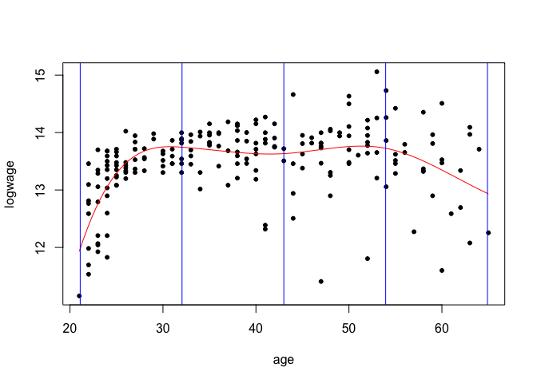

```r
library(splines)
kknots=seq(21+0.1,65-0.1,len=5)
x.grid = seq(21,65,length.out = 100)
age = cps71$age
logwage = cps71$logwage
fit1 = lm(logwage ~ ns(age,knots = kknots ))
pred = predict(fit1,newdata=data.frame(age=x.grid))
plot(age,logwage,pch=20)
lines(x.grid, pred, col="red")
abline(v=kknots, col="blue")
```

### 문제 3.

```r
age = cps71$age
logwage = cps71$logwage
fit2 = smooth.spline(logwage  ~ age, all.knots=T, cv=T, df=10)
```

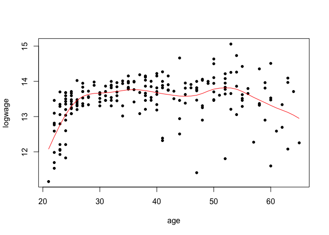

```r
plot(age,logwage,pch=20)
lines(fit2,col="red")
```

### 문제 4.

다음은 `R package` 의 `nlstools`에 있는 `O2K`자료이다. 폐질환이 있는 환자가 처음 5.83분까지는 안정을 취하다가 이후 6분을 걸으면서 산소 흡수량(`VO2`, Oxygen uptake kinetics)을 시간 `t`별로 측정한 값이다.

시간에 따른 산소 흡수량의 변화를 평활스플라인으로 적합하고 추정된 함수식을 그림을 그리시오.

```r
# install.packages("nlstools")
library("nlstools")
data("O2K")
head(O2K)
```

```
##           t      VO2
## 1 0.0000000 377.1111
## 2 0.3333333 333.3333
## 3 0.6666667 352.1429
## 4 1.0000000 328.7500
## 5 1.3333333 369.8750
## 6 1.6666667 394.4000
```

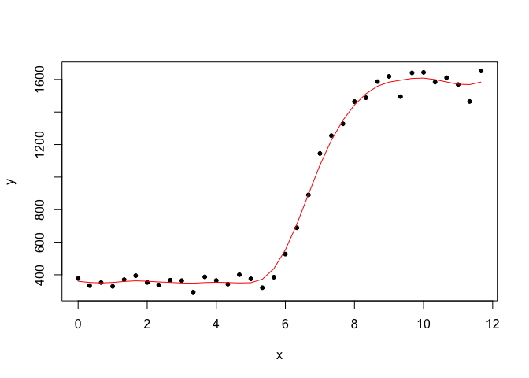

```r
x <- O2K$t
y <- O2K$VO2
fit3 = smooth.spline(y~x, all.knots=T, cv=T)
plot(x,y,pch=20)
lines(fit3,col="red")
```

### 문제 5

위 문제 4에서 사용한 산소흡수량에 대한 자료를 커널회귀모형을 이용하여 적합해 보시오. `R` 에서 커널회귀모형은 함수 `ksmooth`를 사용한다. 다음은 정규분포함수(`normal`)를 커널로 사용하고 구간의 길이를 4로 사용한 경우(`bandwidth = 4`)이다.

구간의 길이를 몇 가지로 선택하여 변화시키면서 가장 적합한 길이를 찾아보시오.

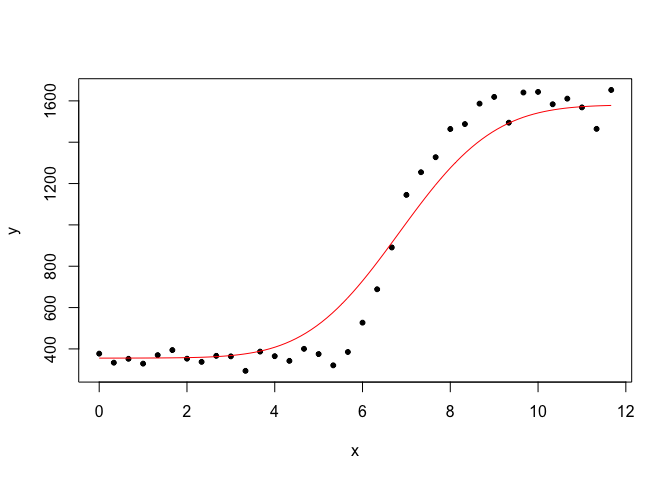

```r
plot(x,y,pch=20)
fit4 <- ksmooth(x, y, "normal", bandwidth = 4)
lines(fit4, col = 2)
```